# Explorative Datenanalyse (EDA) - Teil 2

Andreas Warntjen

28.02.2021

## Inhalt

- Bibliotheken laden und allgemeine Einstellungen
- Daten einlesen und Überblick gewinnen
- Auswertung pro Land (Durchschnittswerte)
- Bi-Variate Zusammenhänge: Datenvisualisierung
- Regressionsanalyse

## Einleitung

In dem ersten Teil hatten wir den Datensatz des World Happiness Reports

- auf fehlende Werte hin untersucht,
- eine neue Variablen mit Angaben zu Regionen (Country groups) für West- und Osteuropa gebildet,
- eine neue Variablen mit den Quartilen der Lebenserwartung für die Länder in West- und Osteuropa gebildet (Life expectancy (quartiles))
- und eine Variable umbenannt (Subjective Wellbeing).

In der Variable Democratic Quality gibt es für das Jahr 2018 fehlende Werte.

Außerdem hatten wir nur die Daten für West- und Osteuropa ausgewählt sowie den Datensatz auf einige Variablen eingeschränkt. Das Ergebnis hatten wir in einer CSV-Datei gespeichert.

In diesem Teil arbeiten wir mit den Daten für Europa weiter und betrachten einige (teilweise aggregierte) deskriptive Statistiken. Am Ende rechnen wir eine einfache OLS-Regression.

## Bibliotheken laden und allgemeine Einstellungen

Neben den Bibliotheken aus Teil 1 laden wir noch matplotlib und seaborn zur Datenvisualisierung.

```python
## Bibliotheken importieren

# Datenimport
import os

# Datenmanipulation und Deskriptive Statistik
import numpy as np
import pandas as pd

# Datenvisualisierung
import matplotlib.pyplot as plt
import seaborn as sns

#Statistische Modelle
import statsmodels.formula.api as sm
import warnings

## Generelle Einstellungen
warnings.filterwarnings('ignore')
```

## Daten einlesen und Überblick gewinnen

Der neue Datensatz liegt in einer CSV-Datei, die wir mit `read_csv` lesen können. Da die Datei aus einem Pandas-Dataframe geschrieben wurde, befindet sich in der ersten Spalte (ohne Spaltenname) der Index. Mit der Einstellung `ìndex_col=0` lesen wir die erste Spalte als Index aus.

```python
## Daten einlesen
source_path=".\Data"
source_filename="WHR2019_Chapter2OnlineData_Europe.csv"
os.chdir(source_path)
# Default für read_csv ist 1. Reihe als Spaltenname (header=0)
# und keine Spalten für den Index; letzteres wird hier geändert
df = pd.read_csv(source_filename, index_col=0)
df.info()
```

```
<class 'pandas.core.frame.DataFrame'>
Int64Index: 355 entries, 71 to 1603
Data columns (total 8 columns):
 #   Column                       Non-Null Count  Dtype
---  ------                       --------------  -----
 0   Country name                 355 non-null    object
 1   Country group                355 non-null    object
 2   Year                         355 non-null    int64
 3   Subjective Wellbeing         355 non-null    float64
 4   Positive affect              355 non-null    float64
 5   Life expectancy (quartiles)  355 non-null    object
 6   Log GDP per capita           353 non-null    float64
 7   Democratic Quality           326 non-null    float64
dtypes: float64(4), int64(1), object(3)
memory usage: 25.0+ KB
```

Die Anzahl "Non-Null Count" der Variablen Democratic Quality (326) ist niedriger als die Zahl der Einträge ("355 entries"). Es gibt also fehlende Werte für diese Variable. Aus dem ersten Teil wissen wir bereits, dass es sich um die Einträge für das Jahr 2018 handelt.

Die Werte der Variable Democratic Quality im Jahr 2018 fehlen alle.

```python
df[df["Year"] == 2018]["Democratic Quality"].unique()
```

```
array([nan])
```

Um die Struktur eines Datensatzes zu verstehen ist es - zumindest bei relativ übersichtlichen Datensätzen - hilfreich sich die ersten Zeilen anzeigen zu lassen. Die Methode `head()` zeigt einige Zeilen an (standardmäßig die ersten fünf). Die Zeilennummer (Index) setzen bei 71 an, weil sie von dem ursprünglichen Datensatz (mit Ländern aus aller Welt) übernommen wurden.

```python
df.head()
```

|  | Country name | Country group | Year | Subjective Wellbeing | Positive affect | Life expectancy (quartiles) | Log GDP per capita | Democratic Quality |
| --- | --- | --- | --- | --- | --- | --- | --- | --- |
| 71 | Austria | Western Europe | 2006 | 7.122211 | 0.823105 | 2. Quartile | 10.657212 | 1.224309 |
| 72 | Austria | Western Europe | 2008 | 7.180954 | 0.832170 | 2. Quartile | 10.701936 | 1.348835 |
| 73 | Austria | Western Europe | 2010 | 7.302679 | 0.814719 | 3. Quartile | 10.676744 | 1.291470 |
| 74 | Austria | Western Europe | 2011 | 7.470513 | 0.789471 | 3. Quartile | 10.702182 | 1.297983 |
| 75 | Austria | Western Europe | 2012 | 7.400689 | 0.822248 | 3. Quartile | 10.704404 | 1.394670 |

Wir sehen, dass es pro Land mehrere Jahre gibt. Wir können uns dies an einem Beispiel genauer angucken.

```python
df[df["Country name"]=="Austria"][["Country name", "Year", "Subjective Wellbeing"]]
```

|  | Country name | Year | Subjective Wellbeing |
| --- | --- | --- | --- |
| 71 | Austria | 2006 | 7.122211 |
| 72 | Austria | 2008 | 7.180954 |
| 73 | Austria | 2010 | 7.302679 |
| 74 | Austria | 2011 | 7.470513 |
| 75 | Austria | 2012 | 7.400689 |
| 76 | Austria | 2013 | 7.498803 |
| 77 | Austria | 2014 | 6.950000 |
| 78 | Austria | 2015 | 7.076447 |
| 79 | Austria | 2016 | 7.048072 |
| 80 | Austria | 2017 | 7.293728 |
| 81 | Austria | 2018 | 7.396002 |

Die Methode `describe()` gibt standardmäßig nur für die numerischen Variablen eine Zusammenfassung. Mit der Parametereinstellung `include="all"` werden alle Variablen angezeigt. Für nicht-numerische Variablen wird dann die Anzahl der verschiedenen Ausprägungen (unique) und die häufigste Ausprägung (top) angegeben.

```python
# Überblick für alle Variablen
df.describe(include="all")
```

|  | Country name | Country group | Year | Subjective Wellbeing | Positive affect | Life expectancy (quartiles) | Log GDP per capita | Democratic Quality |
| --- | --- | --- | --- | --- | --- | --- | --- | --- |
| count | 355 | 355 | 355.000000 | 355.000000 | 355.000000 | 355 | 353.000000 | 326.000000 |
| unique | 31 | 2 | NaN | NaN | NaN | 4 | NaN | NaN |
| top | United Kingdom | Western Europe | NaN | NaN | NaN | 3. Quartile | NaN | NaN |
| freq | 13 | 210 | NaN | NaN | NaN | 92 | NaN | NaN |
| mean | NaN | NaN | 2012.411268 | 6.356516 | 0.721648 | NaN | 10.374421 | 0.893796 |
| std | NaN | NaN | 3.732570 | 0.879001 | 0.093599 | NaN | 0.431043 | 0.408455 |
| min | NaN | NaN | 2005.000000 | 4.380312 | 0.473150 | NaN | 9.135507 | -0.489775 |
| 25% | NaN | NaN | 2010.000000 | 5.694887 | 0.652065 | NaN | 10.129182 | 0.692288 |
| 50% | NaN | NaN | 2013.000000 | 6.357625 | 0.737924 | NaN | 10.397203 | 0.940049 |
| 75% | NaN | NaN | 2016.000000 | 7.099326 | 0.795470 | NaN | 10.672445 | 1.187322 |
| max | NaN | NaN | 2018.000000 | 8.018934 | 0.878256 | NaN | 11.460800 | 1.529229 |

Mit `value_counts()` können wir die Häufigkeitsverteilung kategorischer Variablen betrachten.

```python
df["Country group"].value_counts()
```

```
Western Europe    210
Eastern Europe    145
Name: Country group, dtype: int64
```

Es gibt mehr Beobachtungen für Western Europe als für Eastern Europe. Wie viele Länder gibt es pro Gruppe? Mit einem Filter (**boolean mask**) kombiniert mit `unique()` können wir uns die Ländername pro Country group ausgeben lassen. Das Ergebnis ist ein Numpy array. Die Dimensionen des arrays ermittelt wir mit dem Attribut `shape`.

```python
df[df["Country group"] == "Western Europe"]["Country name"].unique().shape
```

```
(18,)
```

```python
df[df["Country group"] == "Eastern Europe"]["Country name"].unique().shape
```

```
(13,)
```

```python
df["Life expectancy (quartiles)"].value_counts()
```

```
3. Quartile    92
2. Quartile    89
1. Quartile    89
4. Quartile    85
Name: Life expectancy (quartiles), dtype: int64
```

Für alle Länder gibt es mehrere Jahre und damit mehrere Beobachtungen für Subjective Wellbeing. Außerdem haben wir alle Länder einer Ländergruppe zugeordnet. Mit einem Boxplot können wir die Verteilung der Werte für Subjective Wellbeing zwischen den Ländergruppen (über alle Jahre hinweg) vergleichen.

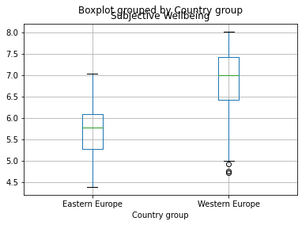

```python
df.boxplot(by="Country group", column="Subjective Wellbeing")
```

Osteuropäische Länder haben niedrigere Werte als Länder in Westeuropa.

## Auswertung pro Land (Durchschnittswerte)

Der Datensatz enthält Daten für die Jahre 2005 bis 2018 für mehrere Länder. Wenn der Vergleich zwischen den Ländern im Vordergrund steht, dann kann man die Daten auf der Ebene der Länder aggregieren. Mit der Methode `groupby` wird ein Datensatz gruppiert. Für einen gruppierten Datensatz können verschiedene Statistiken berechnet werden. Wie wir bereits für das Beispiel Österreich gesehen haben, sind die Daten nicht für alle Länder vollständig von 2005 bis 2018 vorhanden. Mit Hilfe von `groupby` und der Methode `count()` können wir zählen, wie viele Einträge es in der Spalte Year pro Land gibt. Um die Liste nach der Anzahl der Jahre zu sortieren nutzen wir anschließend noch `sort_values()`. Der Parameter `ascending=False` sorgt dafür, dass die Liste absteigend sortiert wird.

```python
df_countries_grp = df.groupby(["Country name"])
df_countries_grp["Year"].count().sort_values(ascending=False)
```

```
Country name
United Kingdom            13
Sweden                    13
Spain                     13
Denmark                   13
Lithuania                 13
France                    13
Germany                   13
Italy                     13
Ireland                   12
Romania                   12
Netherlands               12
Belgium                   12
Latvia                    12
Greece                    12
Estonia                   12
Hungary                   11
Bosnia and Herzegovina    11
Croatia                   11
Slovenia                  11
Serbia                    11
Cyprus                    11
Portugal                  11
Poland                    11
Czech Republic            11
Finland                   11
Austria                   11
Slovakia                  10
Malta                     10
Luxembourg                10
Norway                     8
Switzerland                8
Name: Year, dtype: int64
```

Die Anzahl der Jahre, für die Daten vorliegen, unterscheidet sich zwischen den Ländern. Manche haben nur Daten für 8 Jahre, andere für 13.

Um eine Analyse auf Länderebene durchzuführen, müssen wir die Werte aggregieren. Mit der Methode `agg()` können verschiedene Aggregationsfunktionen (min, max, mean, std) auf einen gruppierten Datensatz angewendet werden.

```python
# Mehrere Aggregationsfunktionen für eine Spalte
df_countries_grp["Subjective Wellbeing"].agg(["mean", "std"]).sort_values("mean", ascending=False)
```

| Country name | mean | std |
| --- | --- | --- |
| Denmark | 7.692072 | 0.172191 |
| Finland | 7.554010 | 0.179375 |
| Norway | 7.549186 | 0.099576 |
| Switzerland | 7.534953 | 0.103910 |
| Netherlands | 7.466531 | 0.089703 |
| Sweden | 7.371575 | 0.106308 |
| Austria | 7.249100 | 0.184722 |
| Ireland | 7.054912 | 0.206791 |
| Luxembourg | 7.011553 | 0.150256 |
| Belgium | 7.010866 | 0.143701 |
| United Kingdom | 6.908503 | 0.175071 |
| Germany | 6.792368 | 0.228729 |
| France | 6.664774 | 0.246413 |
| Czech Republic | 6.563952 | 0.235159 |
| Spain | 6.514385 | 0.384701 |
| Malta | 6.384076 | 0.344295 |
| Italy | 6.257383 | 0.342071 |
| Cyprus | 6.087859 | 0.470613 |
| Slovakia | 6.000420 | 0.296805 |
| Slovenia | 5.960895 | 0.180298 |
| Poland | 5.865575 | 0.195837 |
| Lithuania | 5.764080 | 0.353107 |
| Croatia | 5.548247 | 0.257856 |
| Estonia | 5.531269 | 0.267461 |
| Greece | 5.496580 | 0.564360 |
| Romania | 5.475363 | 0.448037 |
| Portugal | 5.352193 | 0.311528 |
| Latvia | 5.315125 | 0.532209 |
| Hungary | 5.120173 | 0.396097 |
| Bosnia and Herzegovina | 5.086144 | 0.317867 |
| Serbia | 5.082295 | 0.479855 |

Wir können den Spalten mit den aggregierten Werten auch eigene Spaltennamen geben. Dazu übergeben wir `agg()` eine Liste mit Tuples von Spaltennamen und Funktionsnamen. Wenn anschließend über eine Spalte sortiert werden soll, dann muss der neue Spaltenname `sort_values()` übergeben werden.

```python
# Mehrere Aggregationsfunktionen für eine Spalte mit selbst bestimmten Spaltennamen
df_countries_grp["Subjective Wellbeing"].agg([("Durchschnitt", "mean"), ("Abweichung" ,"std")]).sort_values("Durchschnitt", ascending=False)
```

| Country name | Durchschnitt | Abweichung |
| --- | --- | --- |
| Denmark | 7.692072 | 0.172191 |
| Finland | 7.554010 | 0.179375 |
| Norway | 7.549186 | 0.099576 |
| Switzerland | 7.534953 | 0.103910 |
| Netherlands | 7.466531 | 0.089703 |
| Sweden | 7.371575 | 0.106308 |
| Austria | 7.249100 | 0.184722 |
| Ireland | 7.054912 | 0.206791 |
| Luxembourg | 7.011553 | 0.150256 |
| Belgium | 7.010866 | 0.143701 |
| United Kingdom | 6.908503 | 0.175071 |
| Germany | 6.792368 | 0.228729 |
| France | 6.664774 | 0.246413 |
| Czech Republic | 6.563952 | 0.235159 |
| Spain | 6.514385 | 0.384701 |
| Malta | 6.384076 | 0.344295 |
| Italy | 6.257383 | 0.342071 |
| Cyprus | 6.087859 | 0.470613 |
| Slovakia | 6.000420 | 0.296805 |
| Slovenia | 5.960895 | 0.180298 |
| Poland | 5.865575 | 0.195837 |
| Lithuania | 5.764080 | 0.353107 |
| Croatia | 5.548247 | 0.257856 |
| Estonia | 5.531269 | 0.267461 |
| Greece | 5.496580 | 0.564360 |
| Romania | 5.475363 | 0.448037 |
| Portugal | 5.352193 | 0.311528 |
| Latvia | 5.315125 | 0.532209 |
| Hungary | 5.120173 | 0.396097 |
| Bosnia and Herzegovina | 5.086144 | 0.317867 |
| Serbia | 5.082295 | 0.479855 |

Das Ergebnis von `groupby()` und einer Aggregationsfunktion ist ein DataFrame. Standardmäßig wird das Gruppierungsmerkmal (hier: Country name) genutzt, um einen Index für den neuen DataFrame zu bilden. Wenn bei der Definition der Gruppierung `as_index=False` gesetzt wird, ist das Gruppierungsmerkmal in dem neuen Datensatz eine Spalte.

```python
df_countries_grp = df.groupby(["Country name", "Country group"], as_index=False)
df_countries = df_countries_grp[["Subjective Wellbeing", "Log GDP per capita", "Democratic Quality"]].agg("mean")
df_countries.info()
```

```
<class 'pandas.core.frame.DataFrame'>
Int64Index: 31 entries, 0 to 30
Data columns (total 5 columns):
 #   Column                Non-Null Count  Dtype
---  ------                --------------  -----
 0   Country name          31 non-null     object
 1   Country group         31 non-null     object
 2   Subjective Wellbeing  31 non-null     float64
 3   Log GDP per capita    31 non-null     float64
 4   Democratic Quality    31 non-null     float64
dtypes: float64(3), object(2)
memory usage: 1.5+ KB
```

```python
df_countries.head()
```

|  | Country name | Country group | Subjective Wellbeing | Log GDP per capita | Democratic Quality |
| --- | --- | --- | --- | --- | --- |
| 0 | Austria | Western Europe | 7.249100 | 10.700701 | 1.287485 |
| 1 | Belgium | Western Europe | 7.010866 | 10.633887 | 1.044864 |
| 2 | Bosnia and Herzegovina | Eastern Europe | 5.086144 | 9.253980 | -0.289433 |
| 3 | Croatia | Eastern Europe | 5.548247 | 9.958929 | 0.573975 |
| 4 | Cyprus | Eastern Europe | 6.087859 | 10.377584 | 0.792420 |

## Bi-Variate Zusammenhänge: Datenvisualisierung

**pandas** enthält ein paar nützliche Funktionen zur Datenvisualisierung. Wir können uns sehr einfach beispielsweise ein Streudiagramm erstellen. Wir sehen hier den Zusammenhang zwischen GDP per Capita (log) und Subjective Wellbeing.

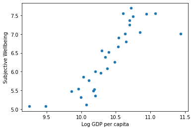

```python
df_countries.plot(kind="scatter", x="Log GDP per capita", y="Subjective Wellbeing")
```

Mit der Seaborn-Bibliothek können wir schnell einen **pairplot** generieren, der für alle numerischen Variablen sowohl die uni-variate Verteilung als auch den bi-variaten Zusammenhang mit allen anderen (numerischen) Variablen anzeigt.

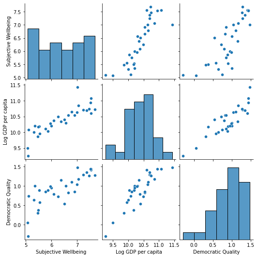

```python
sns.pairplot(df_countries)
```

Standardmäßig wird die uni-variate Verteilung mit Hilfe eines Histogramms dargestellt. Wir können dies jedoch ändern und etwa mit `diag_kind = 'kde'` eine geglättetere Darstellung wählen.

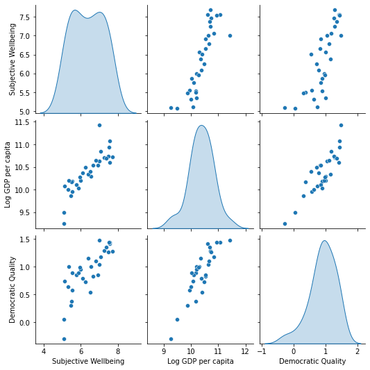

```python
sns.pairplot(df_countries, diag_kind = 'kde')
```

Es scheint einen linearen positiven Zusammenhang zwischen dem Bruttoinlandsprodukt pro Kopf (GDP per capita (log)) sowie der Qualität der Demokratie und dem subjektiven Wohlbefinden zu geben (Subjective Wellbeing). Außerdem scheinen die Qualität der Demokratie und das Bruttoinlandsprodukt korreliert zu sein.

## Regressionsanalyse

Ein Streudiagramm mit der Regressionsgeraden verdeutlicht den Zusammenhang zwischen demokratischer Qualität und subjektiven Wohlbefinden. Wir nutzen dafür die `regplot()` aus **seaborn**.

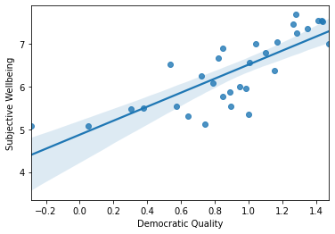

```python
sns.regplot(x=df_countries["Democratic Quality"], y=df_countries["Subjective Wellbeing"])
plt.show()
```

Um mögliche Unterschiede zwischen west- und osteuropäischen Ländern zu berücksichtigen, können wir die beiden Gruppen farblich getrennt darstellen.

```
<function matplotlib.pyplot.show(close=None, block=None)>
```

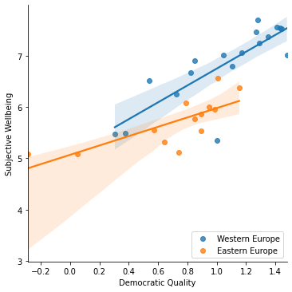

```python
# Mit 'hue' wird die Farbe an eine kategoriale Variable angepasst
sns.lmplot( x="Democratic Quality", y="Subjective Wellbeing", data=df_countries, hue="Country group", fit_reg=True, legend=False)

# Die Legende kann verschoben werden
plt.legend(loc='lower right')

plt.show
```

Die Werte für subjektives Wohlbefinden sind im Schnitt in westeuropäischen Ländern höher als in osteuropäischen Ländern. Außerdem weisen West- und Osteuropa unterschiedliche Wertebereiche für die Qualität der Demokratie auf.

Bevor wir eine Regressionsanalyse rechnen, müssen wir die Spaltennamen (die Leerzeichen enthalten) anpassen. Dazu nutzen wir die **pandas** Funktion `rename()`.

```python
df_countries = df_countries.rename(columns={"Country name" : "Country", "Subjective Wellbeing": "Wellbeing", "Log GDP per capita" : "Log_Wealth", "Democratic Quality" : "Democracy", "Country group" : "Region"})
df_countries.info()
```

```
<class 'pandas.core.frame.DataFrame'>
Int64Index: 31 entries, 0 to 30
Data columns (total 5 columns):
 #   Column      Non-Null Count  Dtype
---  ------      --------------  -----
 0   Country     31 non-null     object
 1   Region      31 non-null     object
 2   Wellbeing   31 non-null     float64
 3   Log_Wealth  31 non-null     float64
 4   Democracy   31 non-null     float64
dtypes: float64(3), object(2)
memory usage: 1.5+ KB
```

Die Bibliothek **statsmodels** stellt eine Reihe statistische/ökonemtrischer Verfahren zur Verfügung. Für dieses einfache Beispiel belassen wir es bei einer simplen OLS-Regression mit `ols()` und nutzen die Eingabe per Formel. Die Ergebnisse werden per `summary()` ausgegeben. Im Hintergrund berücksichtigt `ols()`, dass es sich bei Region um eine kategoriale Variable handelt und zeigt uns den Wert für eine Dummy-Kodierung mit einer der beiden Ausprägungen.

```python
reg_result = sm.ols(formula = "Wellbeing ~ Democracy + Log_Wealth + Region", data = df_countries).fit()
reg_result.summary()
```

OLS Regression Results

| Dep. Variable: | Wellbeing | R-squared: | 0.782 |
| --- | --- | --- | --- |
| Model: | OLS | Adj. R-squared: | 0.758 |
| Method: | Least Squares | F-statistic: | 32.35 |
| Date: | Tue, 02 Mar 2021 | Prob (F-statistic): | 4.37e-09 |
| Time: | 16:46:24 | Log-Likelihood: | -14.865 |
| No. Observations: | 31 | AIC: | 37.73 |
| Df Residuals: | 27 | BIC: | 43.47 |
| Df Model: | 3 |  |  |
| Covariance Type: | nonrobust |  |  |

|  | coef | std err | t | P>\|t\| | [0.025 | 0.975] |
| --- | --- | --- | --- | --- | --- | --- |
| Intercept | -0.5705 | 4.579 | -0.125 | 0.902 | -9.966 | 8.825 |
| Region[T.Western Europe] | 0.4945 | 0.225 | 2.196 | 0.037 | 0.033 | 0.956 |
| Democracy | 0.8680 | 0.428 | 2.026 | 0.053 | -0.011 | 1.747 |
| Log_Wealth | 0.5644 | 0.482 | 1.171 | 0.252 | -0.425 | 1.554 |

| Omnibus: | 7.523 | Durbin-Watson: | 1.544 |
| --- | --- | --- | --- |
| Prob(Omnibus): | 0.023 | Jarque-Bera (JB): | 5.838 |
| Skew: | -0.897 | Prob(JB): | 0.0540 |
| Kurtosis: | 4.140 | Cond. No. | 645. |

Notes:  
[1] Standard Errors assume that the covariance matrix of the errors is correctly specified.